# Bayou Workshop Notebook

##### Challenge question:

1. Joe is unsure of what prior to use for *alpha*, and doesn’t want it to affect his analysis. He decides he wants to use an uniformative prior, so he uses a uniform distribution on *alpha* from 0 to 100. This allows very small (BM-like) and very large (White noise-like) values for *alpha*. How good a choice did Joe make? (Hint: try randomly generating values and converting to phylogenetic half-life)

Second, we’ll set the prior on the stationary variance of the OU process from the Blunderbuss model, as this seems to be the “niche width” we expect to see on million year timescales. We will center it at the estimate from the multiple-burst model from Uyeda et al. 2011. We could make the stationary variance broader than this if we didn’t want to interpret the model as the “multiple-burst” model from Uyeda et al. 2011. For example, you might set the right tail to be something like 1 or 2 times the width of the entire clade’s variance in trait values, and the left tail a few multiples of the population measurement error. This is still a really broad distribution, but even so can constrain the model in ways that often cause Maximum Likelihood based analysis to struggle.

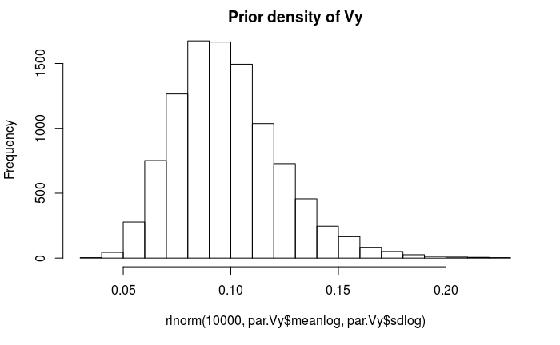

```r
par.Vy <- list(meanlog=log(0.0958), sdlog=0.25)
hist(rlnorm(10000, par.Vy$meanlog, par.Vy$sdlog), main="Prior density of Vy")
```

Let’s make the prior, MCMC object and run the chain. Note that we have specified that *model = “OUrepar”* in *make.prior* and *bayou.makeMCMC*, which means we are using the *halflife*, *Vy* parameterization instead of *sig2* and *alpha*.

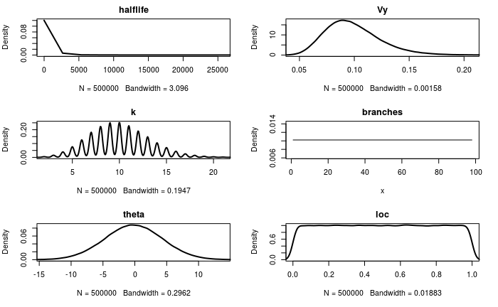

```r
priorBB <- make.prior(tree,
                      dists=list(dhalflife="dlnorm", dVy="dlnorm",
                                 dk="cdpois", dsb="dsb", dtheta="dnorm"),
                      param=list(dhalflife=par.halflife,
                                 dVy=par.Vy,
                                 dk=list(lambda=10, kmax=50), dsb=list(bmax=1, prob=1),
                                 dtheta=list(mean=mean(dat), sd=1.5*sd(dat))),
                      model="OUrepar"
)
```

```r
set.seed(1)
mcmcBB <- bayou.makeMCMC(tree, dat, SE=MEvar, model="OUrepar", prior=priorBB, new.dir="../output/modelBB/", outname="modelBB_r001", plot.freq=NULL)
mcmcBB$run(10000)
```

```
gen     lnL     prior   halflif Vy      rtheta  k       birth.k D0.slid D1.slid death.k .halfli R1.slid .theta  U0.slid U1.slid U2.slid .Vy
1000    -43.25  -61.05  5.79    0.18    -3.18   9       0.11    0.77    0.56    0.56    0.56    1.00    0.52    0.74    0.19    0.20    0.37
2000    -31.71  -77.96  8.85    0.20    0.60    12      0.07    0.91    0.64    0.42    0.56    1.00    0.44    0.72    0.19    0.22    0.40
3000    -25.40  -89.92  4.46    0.16    0.71    15      0.06    0.90    0.56    0.37    0.59    1.00    0.47    0.72    0.28    0.26    0.44
4000    -31.16  -83.78  1.03    0.15    1.07    14      0.06    0.88    0.50    0.34    0.62    1.00    0.48    0.77    0.30    0.32    0.45
5000    -32.73  -64.95  1.10    0.17    0.92    10      0.05    0.85    0.46    0.31    0.63    1.00    0.48    0.79    0.27    0.26    0.44
6000    -36.34  -71.14  4.26    0.17    0.95    11      0.05    0.87    0.43    0.29    0.67    0.67    0.46    0.80    0.26    0.27    0.45
7000    -32.81  -63.46  6.89    0.13    1.04    10      0.04    0.89    0.40    0.28    0.68    0.67    0.45    0.81    0.23    0.24    0.47
```

[output not shown]

```
8000    -34.88  -70.11  8.40    0.14    0.99    11      0.04    0.84    0.36    0.28    0.63    0.67    0.46    0.79    0.22    0.20    0.47
9000    -28.08  -75.99  12.73   0.15    0.97    12      0.04    0.80    0.34    0.27    0.60    0.80    0.47    0.78    0.21    0.20    0.46
10000   -27.42  -69.52  11.60   0.13    1.24    11      0.04    0.79    0.31    0.26    0.56    0.80    0.48    0.76    0.21    0.18    0.46
```

```r
chainBB <- mcmcBB$load()
chainBB <- set.burnin(chainBB, 0.3)
summary(chainBB)
```

```
bayou MCMC chain: 10000 generations
1001 samples, first 300 samples discarded as burnin


Summary statistics for parameters:
                  Mean         SD    Naive SE Time-series SE Effective Size
lnL        -31.4904135 4.15425935 0.156792415    0.958288208      18.792948
prior      -74.1765834 9.74812926 0.367919429    2.462827984      15.666587
halflife     5.6174332 3.98915947 0.150561122    2.422927249       2.710704
Vy           0.1537659 0.02981157 0.001125165    0.004748309      39.417749
k           11.8205128 1.98905156 0.075071914    0.532139111      13.971458
ntheta      12.8205128 1.98905156 0.075071914    0.532139111      13.971458
root.theta   0.9826078 0.27598668 0.010416446    0.038725991      50.789174
all theta   -0.6911857 3.45095862          NA             NA             NA
            HPD95Lower  HPD95Upper
lnL        -38.5136928 -23.4150913
prior      -91.2802570 -53.8478785
halflife     0.3856885  13.0100715
Vy           0.1009517   0.2051942
k            8.0000000  15.0000000
ntheta       9.0000000  16.0000000
root.theta   0.7079973   1.4580308
all theta           NA          NA


Branches with posterior probabilities higher than 0.1:
          pp magnitude.of.theta2 naive.SE.of.theta2 rel.location
93 1.0000000          -1.5724011        0.012445816   0.55002311
97 0.9985755          -2.5065644        0.015433045   0.48741302
11 0.9658120          -3.0505873        0.012761872   0.42335658
49 0.8376068          -2.3930953        0.006635819   0.47098236
72 0.8290598          -0.5351987        0.015694054   0.47496208
69 0.7578348          -3.8881748        0.067218185   0.47483644
45 0.6794872           6.4107900        0.028185907   0.78586639
70 0.6239316          -3.8422055        0.016757880   0.26540165
77 0.5441595          -1.0491840        0.080924661   0.48337989
71 0.4173789          -3.4750347        0.108801855   0.52682118
46 0.3974359          -1.9169314        0.016850884   0.22214072
42 0.3931624           8.6743020        0.054316567   0.87938667
47 0.3205128           5.6325579        0.010292048   0.64829489
86 0.2236467          -2.2857405        0.265756844   0.01363318
50 0.1923077           0.9990966        0.188055832   0.27125763
74 0.1794872           0.4167583        0.078674298   0.34835747
12 0.1780627           1.2955610        0.015478150   0.17619350
60 0.1495726          -7.0154295        0.151507690   0.00000000
51 0.1396011          -0.4345882        0.031727986   0.00000000
48 0.1182336          -2.4425461        0.012656898   0.25914507
22 0.1082621          -2.6905402        0.033601289   0.32604173
```

```r
plot(chainBB)
```

[output not shown]

```r
par(mfrow=c(2,2))
plotBayoupars(truepars, tree, main = "True parameters")
plotSimmap.mcmc(chainBB, burnin = 0.3, pp.cutoff = 0.3)
```

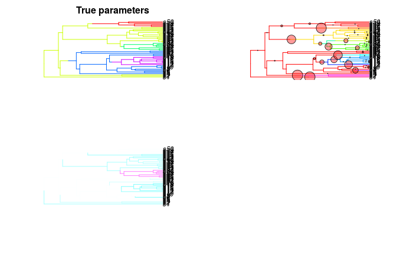

```r
plotBranchHeatMap(tree, chainBB, "theta", burnin = 0.3, pal = cm.colors)
phenogram.density(tree, dat, burnin = 0.3, chainBB, pp.cutoff = 0.3)
```

Likely, we will have more shifts because we made the prior on *Vy* so narrow. Let’s compare the posteriors from the two models.

```r
quantile(chainOU$sig2/(2*chainOU$alpha), quantiles)
```

```
        0%         1%       2.5%        25%        50%        75%      97.5%
 0.1583619  0.2005780  0.2217629  0.3020794  0.3715258  0.4795332  2.4994137
       99%       100%
 4.2490451 11.1666069
```

```r
quantile(chainBB$Vy, quantiles)
```

```
       0%        1%      2.5%       25%       50%       75%     97.5%
0.1009517 0.1017448 0.1047283 0.1388917 0.1600465 0.1881853 0.4145393
      99%      100%
0.5722463 0.5722463
```

###### Challenge

For *chainOU* and *chainBB*, plot phylogenetic half-life and stationary variance from the posterior for both of them on the same plot. Give the points different colors. What does the relationships look like? Are they related? Why? Compare to a plot of *alpha* and *sig2* for both.

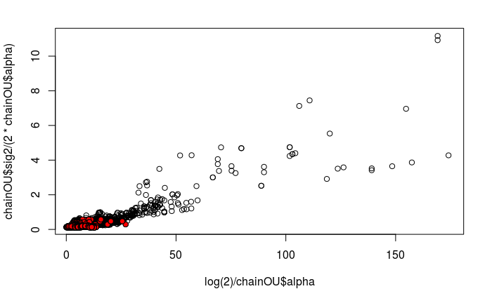

```r
plot(log(2)/chainOU$alpha, chainOU$sig2/(2*chainOU$alpha))
points(chainBB$halflife , chainBB$Vy , pch=21, bg="red")
```

# Quantitative Genetics Model

We can also fit a model that follows the Quantitative Genetics parameterization. You can check the specified prior distributions on your own, but these are informative priors that specify moderate to high heritability, realistic phenotypic variances, large uncertainty regarding the strength of selection and reasonable effective population sizes for entire species.

```r
par.h2 <- list(shape1=10, shape2=10)
par.P <- list(meanlog=log(0.12), sdlog=0.2)
par.w2 <- list(meanlog=log(100), sdlog=2.5)
par.Ne <- list(meanlog=log(500000), sdlog=2.5)
```

We should rescale the branch lengths to correspond roughly to generation time. However, here we will assume that for most of the history of birds and mammals, the generation time has been around 2 year/gen.

```r
QGtree <- tree
QGtree$edge.length <- QGtree$edge.length/2
```

```r
priorQG <- make.prior(QGtree, plot.prior=FALSE,
                      dists=list(dh2="dbeta", dP="dlnorm",
                                 dw2="dlnorm", dNe="dlnorm",
                                 dk="cdpois", dtheta="dnorm"),
                      param=list(dh2=par.h2,
                                 dP=par.P,
                                 dw2=par.w2,
                                 dNe=par.Ne,
                                 dk=list(lambda=10, kmax=50), dsb=list(bmax=1, prob=1),
                                 dtheta=list(mean=mean(dat), sd=1.5*sd(dat))),
                      model="QG"
)
```

```r
set.seed(1)
mcmcQG <- bayou.makeMCMC(QGtree, dat, SE=MEvar, model="QG", startpar=NULL, prior=priorQG, new.dir="../output/modelQG/", outname="modelQG_r001", plot.freq=NULL)
mcmcQG$run(10000)
```

```
gen     lnL     prior   h2      P       w2      Ne      rtheta  k       birth.k D0.slid D1.slid death.k .h2     .Ne     .P      .theta  U0.slid U1.slid U2.slid .w2
1000    -65.20  -124.29 0.71    0.57    27.86   6.42    0.51    12      0.11    0.75    0.17    0.50    0.14    0.57    0.54    0.56    0.58    0.09    0.36    0.25
2000    -57.34  -96.43  0.47    0.17    10.40   1.05    -0.44   13      0.09    0.80    0.26    0.52    0.26    0.58    0.57    0.71    0.65    0.23    0.35    0.35
3000    -57.76  -80.23  0.58    0.13    7.13    0.49    -0.39   10      0.08    0.84    0.27    0.52    0.28    0.54    0.53    0.74    0.72    0.20    0.32    0.37
4000    -48.28  -94.65  0.67    0.14    9.86    1.49    0.52    13      0.08    0.90    0.36    0.52    0.29    0.53    0.49    0.76    0.75    0.20    0.37    0.37
5000    -41.76  -88.62  0.58    0.12    8.30    1.87    0.72    12      0.07    0.84    0.33    0.49    0.28    0.53    0.47    1.00    0.75    0.74    0.18    0.31    0.36
6000    -42.05  -75.34  0.66    0.14    6.65    1.21    0.83    9       0.07    0.78    0.30    0.48    0.27    0.53    0.46    1.00    0.75    0.72    0.15    0.27    0.34
7000    -43.36  -100.18 0.58    0.12    5.62    0.96    0.84    14      0.07    0.81    0.31    0.48    0.28    0.53    0.46    1.00    0.75    0.73    0.16    0.25    0.34
8000    -29.66  -101.48 0.57    0.12    4.97    1.90    1.11    15      0.07    0.81    0.29    0.47    0.27    0.51    0.44    1.00    0.73    0.75    0.14    0.24    0.34
9000    -37.23  -107.85 0.68    0.14    7.31    1.80    1.22    16      0.06    0.80    0.27    0.45    0.26    0.52    0.45    0.83    0.71    0.72    0.13    0.24    0.34
10000   -27.83  -127.36 0.50    0.12    6.51    2.22    -2.55   20      0.06    0.79    0.27    0.44    0.26    0.52    0.45    0.75    0.71    0.71    0.13    0.23    0.33
```

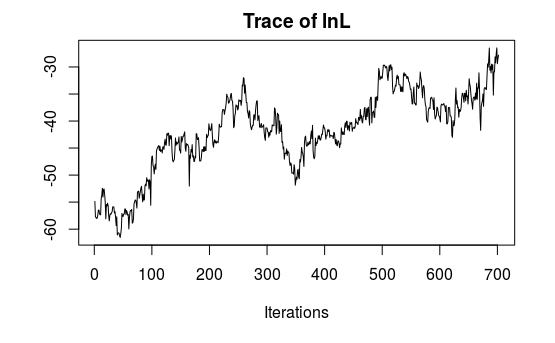

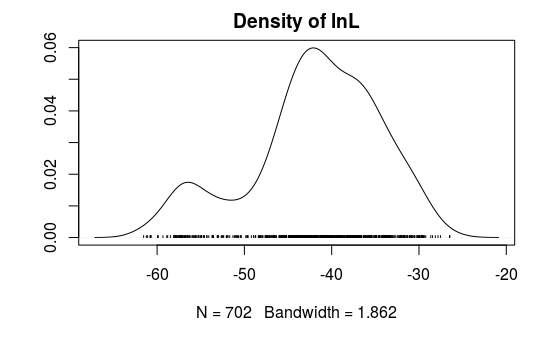

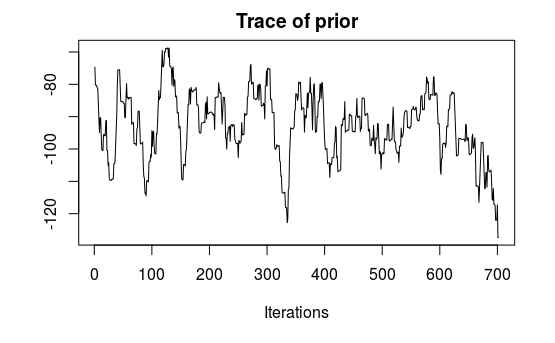

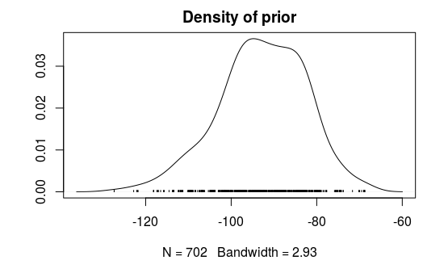

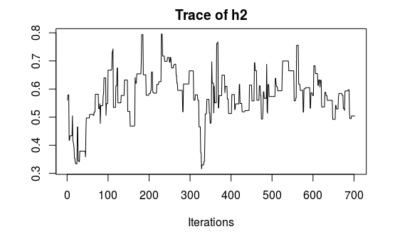

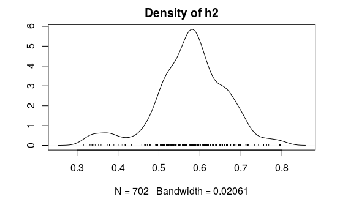

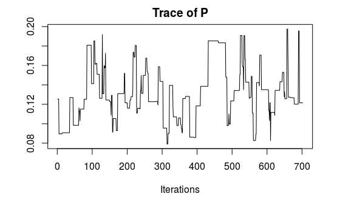

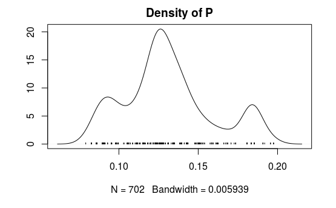

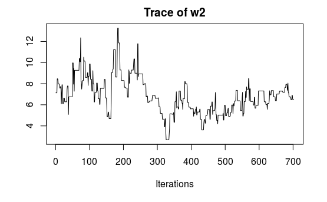

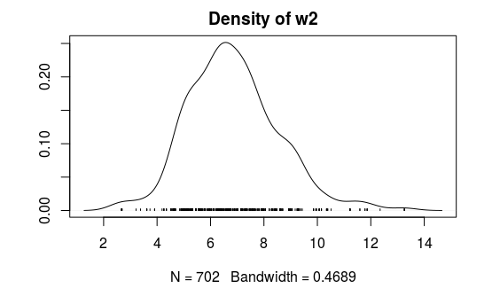

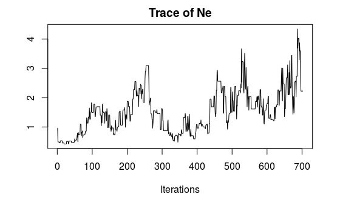

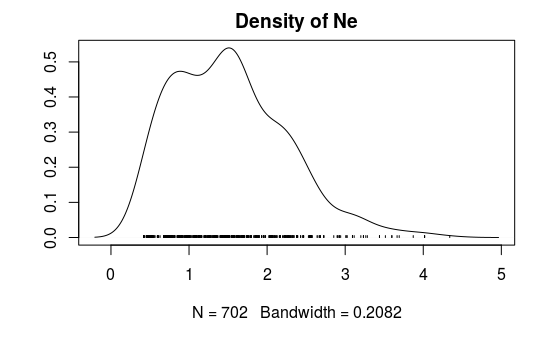

[6 more figures not shown]

```r
par(mfrow=c(2,2))
plotBayoupars(truepars, tree, main = "True parameters")
plotSimmap.mcmc(chainQG, burnin = 0.3, pp.cutoff = 0.3)
```

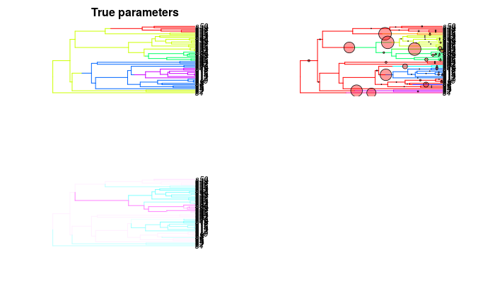

```r
plotBranchHeatMap(tree, chainQG, "theta", burnin = 0.3, pal = cm.colors)
phenogram.density(tree, dat, burnin = 0.3, chainQG, pp.cutoff = 0.3)
```

If you kept the seed the same, you should see that there are many more shifts recovered. This is because the QG model predicts such small stationary variances that shifts must occur costantly to explain the variation among species.

# Model Comparison

Alternative parameterizations, shift locations, and priors can be compared using Bayes Factors. This requires estimation of the marginal likelihood, which can be difficult. **bayou** uses stepping-stone sampling to estimate the marginal likelihoods. To estimate marginal likelihoods, using the ‘$steppingstone’ function in the mcmc object. For this exercise, we will do a much shorter run than is recommended. If you have multiple cores available on your machine, you can make use of these to run the stepping stone analysis in parallel and conduct the analysis much faster.

While I have the complete code to do all 3 runs here, I suggest you partner with your neighbor and divide up the computational burden among you.

```r
registerDoParallel(cores=5)
Bk <- qbeta(seq(0,1, length.out=5), 0.3,1)
ssOU <- mcmcOU$steppingstone(10000, chainOU, Bk, burnin=0.3, plot=FALSE)
ssBB <- mcmcBB$steppingstone(10000, chainBB, Bk, burnin=0.3, plot=FALSE)
ssQG <- mcmcQG$steppingstone(10000, chainQG, Bk, burnin=0.3, plot=FALSE)
mlnL <- c("OU"=ssOU$lnr, "BB"=ssBB$lnr, "QG"=ssQG$lnr)
mlnL
```

```
        OU         BB         QG
 -89.26413 -111.96295 -102.05999
```

If you get a couple errors it’s probably OK, the algorithm takes the posterior and tries to fit various distributions to the parameters, and if it fails to optimize them it will throw an error or two. However, as long as one of them fits OK it will run. Again, we have not run these for long enough or for enough steps (we prefer more like 50!), but you get the idea for how you would proceed. Obviously, having more cores makes this go a LOT faster, and this is a computationally intensive procedure!

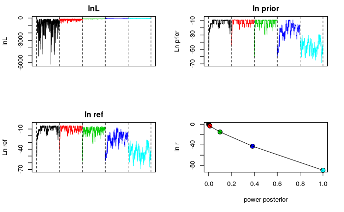

```r
plot(ssOU)
```

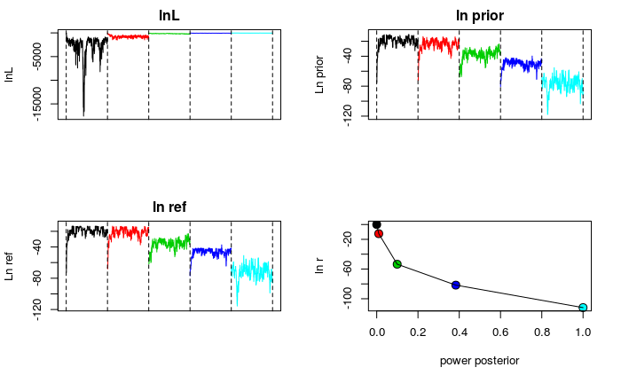

```r
plot(ssBB)
```

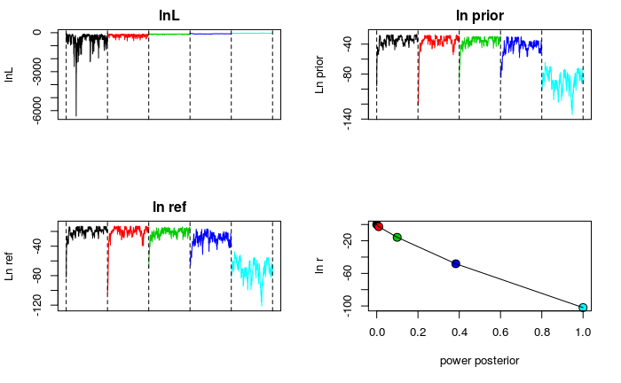

```r
plot(ssQG)
```

##### Challenge:

1. Wait a minute! Won’t a more general model have a higher likelihood than a more restricted model? (Hint: Google *Lindley’s Paradox*)